# Visualisation Project

Michael Polonskiy

2022-06-30

# Topic and Scope

In the digital era electronic devices have become indispensable. From our smartphone to our electronic washing machine, all our lives virtually depend on these little helpers. However at the core of all this transition lies the computer, which nowadays is the most important tool for getting work done. Almost no job can be executed properly without one. Long gone are the days of big, heavy stay at home computers, modern portable laptops are dominating the entire landscape. With these thoughts at hand it is time to dig a little bit deeper, into the different companies that build these marvelous devices and analyze what criteria determine their price and performance.

We collected data reflecting roughly 900 different models of the recent years with their hardware configuration and manufacturer information. Since it is quite difficult to compare models utilizing different components, we extended the given information by recognized CPU and GPU benchmarks, rating each component for its performance. In order to improve readability and understanding of these metrics, which are usually in a specific scale chosen by the benchmarking system, we scaled and converted these metrics to a range of 1 to 100, where 100 is the best possible result a hardware component can achieve. Moreover we combined the two main rating scores for CPU and GPU units to a new metric, which qualifies the overall laptop hardware performance on a range from 1 to 100 respectively.

Note: To simplify the readability of this document the main pre-processing is done in a separate file, called “Data Processing.py”. We have used python for this task, because on the one hand integrating both languages posed a technical challenge, which was interesting to solve, thus exploring and learning about the reticulate package. On the other hand, pythons more programming oriented approach was very helpful when thinking on object-oriented terms, using functions and specific python libraries.

Note: All necessary files are provided within this GitHub Repository. The used datasets were obtained from kaggle.com under the following links:

- Laptop Prices: https://www.kaggle.com/datasets/ionaskel/laptop-prices
- Rating of Intel and AMD processors: https://www.kaggle.com/datasets/fiftin/intel-and-amd-processors
- GPU Benchmarks Compilation: https://www.kaggle.com/datasets/alanjo/gpu-benchmarks

```r
# Libraries
library(reticulate)
library(tidyverse)
library(Metrics)
library(GGally)
library(jtools)
library(ggpubr)
library(rworldmap)
library(ggplot2)
library(scales)
library(sf)
library(rnaturalearth)
library(rnaturalearthdata)
library(ggrepel)
library(gghighlight)
library(ggsflabel)
library(ggtext)
library(lubridate)
library(RColorBrewer)
library(scales)
library(gridExtra)
library(grid)
```

```r
# Resetting python to look for virtual environments in this project
Sys.setenv(RETICULATE_PYTHON = here::here("~/.virtualenvs/VisualizationProject/Scripts/python.exe"))

# Installing virtual environment with packages
# reticulate::virtualenv_install("VisualizationProject", packages =c("pandas","numpy"))

# Setting virtual environment to use for python integration
reticulate::use_virtualenv("VisualizationProject")
```

```r
# Executing python script with pre processing steps
source_python("Data Processing.py")
df <- py$df
```

```r
df$ScaledRating <- rescale((0.5 * scale(df$ProcessorRating, center=FALSE) + 0.25 * scale(df$G2Dmark, center=FALSE) + 0.25 * scale(df$G3Dmark, center=FALSE)), to=c(1,100))
df$PricePerformance <- ( df$Price_euros / df$ScaledRating )
df$ScaledGPU <-  rescale( scale(df$G3Dmark, center=FALSE) +  scale(df$G2Dmark, center=FALSE), to=c(1,100))
df$ScaledCPU <- rescale( df$ProcessorRating, to=c(1,100))
df$RatingBin <- cut(df$ScaledRating, breaks=c(0,10,20, 30, 40, 50,60,70,80,90,100), labels=FALSE)
df$Ram <- as.numeric(df$Ram)
df$combinations = paste0(df$Cpu,'\n',df$Gpu)
```

Although pre-processing is done in python we will create the main metrics used in this analysis in R, since it is easier to use the functions provided in R for this task once the dataset is pre-processed.

```r
#Main Theme object and colors

size <- 15
theme <- theme_bw(base_size = 15) + theme(plot.title = element_text(hjust = 0.5, size = 20, color="black"),  plot.title.position = 'panel', text = element_text(size = size, color="black"),
                            axis.text.x = element_text(size = size, color="black"),  axis.text.y = element_text(size = size, color="black"),
                            axis.title.y = element_text(size = size, color="black"),  axis.title.x = element_text(size = size, color="black"),
                            legend.title=element_text(size = size, color="black"), legend.text=element_text(size = size, color="black"))

colorsinv = c("green4", "green1", "yellow3","red1", "red4")
colors = c("red4", "red1", "yellow3", "green1", "green4")
```

# Influences of GPU and CPU on Price

With this information at hand we want to take a closer look, on the defined performance measures and their influence on a device. First of all we want to inspect how GPU and CPU influence laptop prices and how they influence each other:

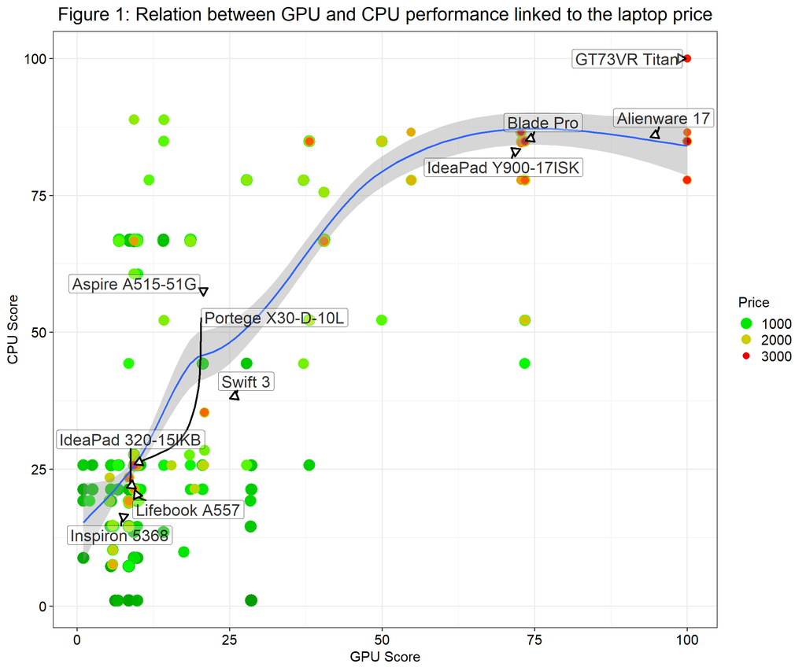

```r
subset <- bind_rows(df %>% group_by(Product) %>%  summarise(Priced_euros=mean(Price_euros),ScaledGPU=mean(ScaledGPU), ScaledCPU=mean(ScaledCPU)) %>% arrange(-Priced_euros) %>% head(5),
                    df %>% group_by(Product) %>%  summarise(Priced_euros=mean(Price_euros),ScaledGPU=mean(ScaledGPU), ScaledCPU=mean(ScaledCPU)) %>% arrange(Priced_euros) %>% slice(81:85))


df %>%  ggplot(aes(x=ScaledGPU, y=ScaledCPU)) +

        geom_point(aes(color=Price_euros, size=Price_euros)) +

        geom_smooth() +

        scale_color_gradientn(colors = colorsinv, n.breaks= 5) +

        scale_size_binned(n.breaks= 5) +

        scale_size(trans = "reverse") +

        guides(color= guide_legend(), size=guide_legend()) +

        theme(plot.title = element_text(hjust = 0.5), plot.title.position = 'panel') +

        geom_label_repel( data=subset, aes(label = Product), size = 6, color = alpha("black", 0.8),
                    force = 50, seed = 20, min.segment.length = 0.1, segment.curvature = -0.4,
                    segment.size = 1, segment.color = "black", arrow = arrow(length = unit(0.015, "npc"),
                    ends = "last", type = "closed"), fill = alpha("transparent", .3), max.overlaps = 10)  +

        labs(title = "Figure 1: Relation between GPU and CPU performance linked to the laptop price", color="Price", size="Price", x="GPU Score", y="CPU Score") +

        theme
```

Looking at the diagram above, we can see our defined metrics, ranging from 0 to 100 on the two main axis, with the price split into three categories, laptops under 1000 euros, laptops between 1000 and 2000 euros and devices above 3000 euros. GPU and CPU score clearly have a strong positive correlation, indicated by the blue regression line. From 0 to about 75 in GPU score we can observe a linear trend, with a slope higher than 1, indicating that by raising GPU power we see a stronger raise in CPU power.

It is obvious that devices with a lower score at both metrics will be in a cheaper range, e.g. the Lifebook A557. At the far end of the plot, in the upper right corner we can see premium laptops, ranking high in both categories and costing a little fortune, like the DELL Alienware series for gaming. However what is most interesting to see, is that there is a trade off with regards to price when considering mainly one of the two metrics. Points in the upper left corner indicate laptops with a high CPU performance, still under 1000 euros. The same goes for devices in the lower right part of the graph, showing an increased GPU rating but moderate pricing. Comparing these two sections we can observe, that high CPU power can be achieved much cheaper than GPU power. GPU seems to be the main factor for driving the cost and after a certain threshold, upgrading GPU does not change the CPU performance, only the price will rise. Therefore our main observation is, that when considering to buy a new device, high CPU is desirable, whereas good GPU performance comes with a lot of cost. It is worth spending a couple of hundred euros more, getting a significantly better CPU, but it could be wise, to save on GPU when not necessarily needed.

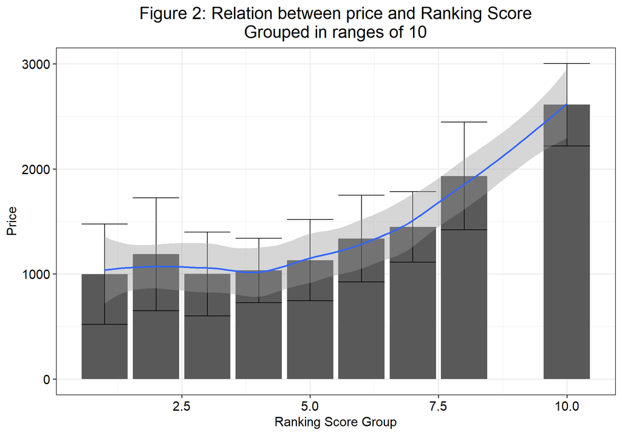

```r
data <- df %>% group_by(RatingBin) %>% summarise(price_mean = mean(Price_euros), price_sd=sd(Price_euros), n=n()) %>% filter(n > 10)

data %>%
  ggplot(aes(x=RatingBin, y=price_mean)) +

  geom_bar(stat="identity") +

  geom_errorbar(aes(ymin=price_mean-price_sd, ymax=price_mean+price_sd)) +

  geom_smooth(smoothing=FALSE) +

  labs(title = "Figure 2: Relation between price and Ranking Score\nGrouped in ranges of 10", color="Price", size="Price", x="Ranking Score Group", y="Price") +

  theme
```

# Finding the right CPU and GPU

## Investigating CPUs

Knowing now that there exists an optimum when buying a laptop, the logical question of the intrigued buyer will be: “How do I recognize this sweet spot? Which CPU / GPU should I now buy?” To answer this question, we want to investigate the most common CPUs and GPUs in laptops and see, which of them display the best price-performance ratio. Therefore we introduce a new metric: price-performance ratio, this metric tells us how much one point of standardized performance (1-100) will cost us with a specific device.

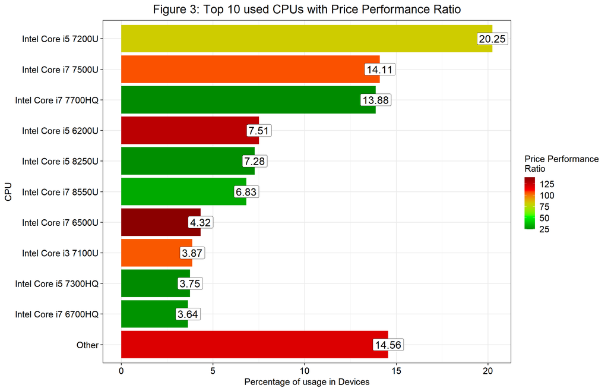

```r
topn <- 10
total <- count(df)$n

dataCPU <- df %>% group_by(Cpu) %>% summarise(n=n(), meanPricePerformance = mean(PricePerformance)) %>% arrange(desc(n)) %>%
            group_by(Cpu = factor(c(Cpu[1:topn ], rep("Other", n() - topn)), levels=c("Other",Cpu[topn:1])))  %>%
            summarise(n=sum(n) , meanPricePerformance = mean(meanPricePerformance), percentage=n/total * 100)  %>% arrange(desc(n))


dataCPU %>%  ggplot(aes(x=Cpu, y=percentage, fill=meanPricePerformance)) +

        geom_bar(stat="identity") + coord_flip() +

        scale_fill_gradientn(colors = colorsinv, n.breaks= 5) +

        geom_label(aes(label=round(percentage,2)), fill="white", size=6) +

        labs(title = "Figure 3: Top 10 used CPUs with Price Performance Ratio", fill="Price Performance\nRatio", y="Percentage of usage in Devices", x="CPU") +

        theme
```

## Investigating GPUs

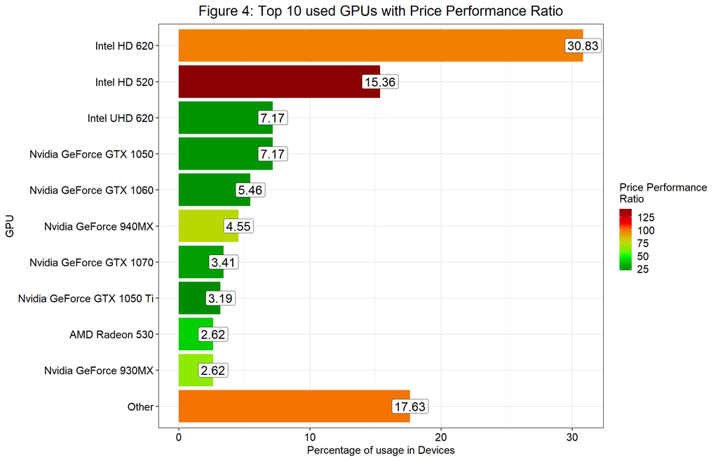

```r
dataGPU <- df %>% group_by(Gpu) %>% summarise(n=n(), meanPricePerformance = mean(PricePerformance)) %>% arrange(desc(n)) %>%
            group_by(Gpu = factor(c(Gpu[1:topn ], rep("Other", n() - topn)), levels=c("Other",Gpu[topn:1]))) %>%
            summarise(n=sum(n) , meanPricePerformance = mean(meanPricePerformance), percentage=n/total * 100)  %>% arrange(desc(n))


dataGPU %>% ggplot(aes(x=Gpu, y=percentage, fill=meanPricePerformance)) +

        geom_bar(stat="identity") + coord_flip() +

        scale_fill_gradientn(colors = colorsinv, n.breaks= 5) +

        geom_label(aes(label=round(percentage,2)), fill="white", size=6) +

        labs(title = "Figure 4: Top 10 used GPUs with Price Performance Ratio", fill="Price Performance\nRatio", y="Percentage of usage in Devices", x="GPU") +

        theme
```

Turning now to GPU analysis, we can see the same kind of plot depicted for GPUs, with the color again indicating the price-performance ratio of a graphics card. It is interesting to note, that here once again the first couple of GPUs make up a large share of the overall cards available, the first 4 having roughly 60 % market share. However, the distribution is different, since Intel HD 620 GPUs take up more than 30 % by their own. Considering the price-performance ratio we can observe, that roughly 45 % of GPUs installed (being Intel HD 620 or Intel 520) are quite undesirable. The difference in naming of intels onboard GPUs is quite significant, since GPUS with the prefix “U” perform fairly well with Intel UHD 620 at roughly 25 euro/point, especially compared to their dominant sibling Intel HD 620 at about 90 euro/point. Moreover we can observe, that external GPUs like the Nvidia GeForce GTX series are much better in terms of price-performance ratio than their onboard intel competitors. Therefore when looking out for new hardware two main things should be memorized, when it comes to GPUs: Either look for external GPUs or examine closely which kind of GPU is installed on your device, it seems like manifacturers earn a great deal by selling two different types of onboard GPU with very similar naming.

Using our results from these two analysis we can safely pose the question: Which is the Hardware combination which occurs most frequent in laptops sold and which of these combinationsa are now desirable, based on our knowledge?

## Bringing it all together: Investigating Hardware

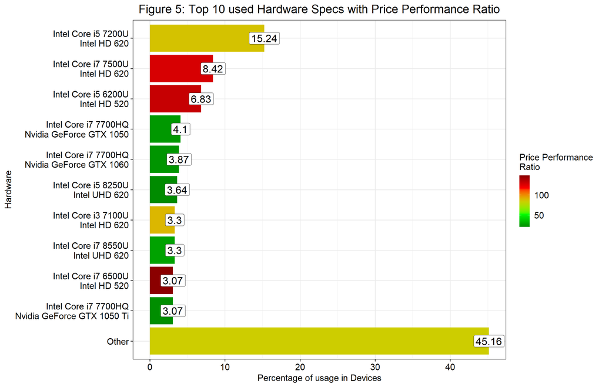

```r
subset <- df %>% group_by(combinations) %>% summarise(n=n(), meanPricePerformance = mean(PricePerformance)) %>% arrange(desc(n)) %>%
                 group_by(combinations = factor(c(combinations[1:topn ], rep("Other", n() - topn)), levels=c("Other",combinations[topn:1]))) %>%
                 summarise(n=sum(n) , meanPricePerformance = mean(meanPricePerformance), percentage=n/total * 100)  %>% arrange(desc(n)) %>% top_n(5)



data <- df %>% group_by(combinations) %>% summarise(n=n(), meanPricePerformance = mean(PricePerformance)) %>% arrange(desc(n)) %>%
        group_by(combinations = factor(c(combinations[1:topn ], rep("Other", n() - topn)), levels=c("Other",combinations[topn:1]))) %>%
        summarise(n=sum(n) , meanPricePerformance = mean(meanPricePerformance), percentage=n/total * 100)  %>% arrange(desc(n))

data %>% ggplot(aes(x=combinations, y=percentage, fill=meanPricePerformance)) +

         geom_bar(stat="identity") + coord_flip() +  scale_fill_gradientn(colors = colorsinv, n.breaks= 5) +

         geom_label(aes(label=round(percentage,2)), fill="white", size=6) +

         labs(title = "Figure 5: Top 10 used Hardware Specs with Price Performance Ratio", fill="Price Performance\nRatio", y="Percentage of usage in Devices", x="Hardware") +

         theme
```

Summing up this analysis we can say, that high performance CPUs appear with external GPUs which makes them a good buy. The same recommendation can be given out to i5 CPUs with UHD graphics. HD GPUs should be avoided at all costs, which could prove itself to be quite difficult since they seem to be found in devices most often.

Now that we have identified the best Hardware components, we want to take a look at the manufacturers, to identify which of them should be preferred.

# Taking a closer look at the manufacturers

```r
size <- 28
theme2 <- theme_bw(base_size = 15) + theme(plot.title = element_text(hjust = 0.5, size = 35, color="black"),  plot.title.position = 'panel', text = element_text(size = size, color="black"),
                            axis.text.x = element_text(size = size, color="black"),  axis.text.y = element_text(size = size, color="black"),
                            axis.title.y = element_text(size = size, color="black"),  axis.title.x = element_text(size = size, color="black"),
                            legend.title=element_text(size = size, color="black"), legend.text=element_text(size = size, color="black"), strip.text.x = element_text(size = size))
```

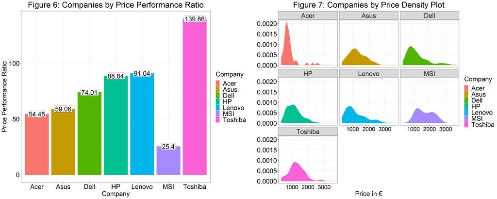

```r
data <- df %>% group_by(Company) %>% summarise(n = n(), PricePerformance = mean(PricePerformance), sd = sd(PricePerformance)) %>% filter(n > 10)

fig6 <- data   %>%  ggplot(aes(x=Company, y=(PricePerformance), fill=Company, color=Company)) +

                    geom_bar(stat="identity") +

                    geom_label(aes(label=round(PricePerformance,2)), fill="white", color="black", size=10) +

                    labs(title = "Figure 6: Companies by Price Performance Ratio", fill="Company", color="Company", y="Price Performance Ratio", x="Company") +

                    theme2


data <- df %>% group_by(Company) %>% summarise(n = n()) %>% merge(df) %>% filter(n > 10)


fig7 <- data %>% ggplot(aes(Price_euros, fill=Company, color=Company)) +

                 geom_density() + facet_wrap(~ Company) +

                 labs(title = "Figure 7: Companies by Price Density Plot", fill="Company", color="Company", y="", x="Price in €") +

                 theme2 + theme(axis.text.x = element_text(size = 25, color="black"))


ggarrange(fig6,fig7)
```

Investigating figure 6, we see all companies ranked by their price performance ratio. It is easy to see, that MSI is by far the best choice with regards to price performance with 25.4 euro/point. The second best choice is Acer, however the gap between the two is quite large, with Acer being at 54.45 euro/point. Coming in third by a close margin to Acer is Asus, with 59.06 euro/point. All other companies have significantly higher values, with Toshiba being last.

# Summary

Summing up our results we can say, that we have analyzed the laptop landscape thoroughly and identified several key features for which one should look out for, if the time has come to buy a new device. First and foremost performance does increase with price, however getting a good CPU is much easier and cheaper, than finding a decent GPU. Buyers who try to get “the biggest bang for their buck” should therefore look out for Intels UHD GPU series, since it is unrivaled in terms of its price performance ratio. In general if a light laptop with an energy efficient CPU is needed, i5 CPUs should be preferred, unless extra computing power is absolutely necessary. If a larger budget is available laptops with a high performance CPU (HQ) as well as with a dedicated GPU should be considered. Lastly, when choosing a device with respect to the manufacturer, MSI is the best choice for greater investments that will last a long time, whereas Acer should be considered if pricing is key.

Note: Although this article offers a solid recommendation on which device to buy, several observations should be kept in mind: Due to some difficulties with regards to data acquisition and preparation, not all major companies present in the market have been analyzed. Especially Apple devices which are quite popular, have been left out, due to insufficient data points. Moreover with regards to hardware specifications Intel is the dominating manufacturer, therefore most of this analysis has focused on its vast product lineup. However amd is becoming more dominant in recent time, therefore a follow up article with a detailed investigation of amd hardware is to be expected.